# Dominance Through the Lens of a Competitive Worldview

Study 2: Analysis Report

# Background

The purpose of Study 2 was to test the external validity of our model. To that end, instead of relying on scales of dominant strategies at the workplace (as was done in Study 1), we crowd-sourced real-world instances of managerial dominance. So, we first asked full or part-time employees to recall a time in which they manager (or previous manager) behaved dominantly in order to induce compliance. We then pooled from those descriptions and asked participants to estimate the impact of that behavior on the relationship between the manager and employee. Then, participants indicated the extent to which they would have behaved dominantly if they were the manager in the same situation.

# Preregistered hypotheses

This study was preregistered here: [Open Science Framework](https://osf.io/493q6/?view_only=ba0c4d08a7344522b8d0ab2557ac4c07)

1. Competitive worldview will be positively associated with perceived relational benefit from managers’ dominant behaviors (i.e., those higher in competitive worldview will perceive fewer relational costs to dominant behaviors).
2. Competitive worldview will be positively associated with self-reported hypothetical dominant behavior as a manager.
3. The relationship between competitive worldview and self-reported hypothetical dominant behavior as a manager will be at least partially explained by perceived relational benefit from dominant behaviors.

# Data collection

We collected descriptions of managerial dominance during March 2024. Then, after finalizing the pool of descriptions (23 total), we sampled 300 participants on Apr. 8th, 2024 through Connect by CloudResearch.

We excluded participants who failed one preregistered attention check, as well as those who got through the platforms filter despite not being full- or part-time employees.

```r
n_eligible <- df_s2 %>%
  group_by(elg) %>%
  summarise(N = n()) %>%
  ungroup() %>%
  filter(elg == 1) %>%
  select(N) %>%
  unlist() %>%
  unname()

passed_checks <- df_s2 %>%
  group_by(att_1) %>%
  summarise(N = n()) %>%
  ungroup() %>%
  filter(att_1 == 1) %>%
  select(N) %>%
  unlist() %>%
  unname()

df_s2 %>%
  group_by(att_1) %>%
  summarise(N = n()) %>%
  ungroup() %>%
  mutate(Perc = round(100*(N/sum(N)),2)) %>%
  ungroup() %>%
  kbl() %>%
  kable_styling(bootstrap_options = "hover",
                full_width = F,
                position = "left")
```

| att_1 | N | Perc |
| --- | --- | --- |
| 0 | 7 | 2.33 |
| 1 | 294 | 97.67 |

```r
df_s2 %>%
  filter(att_1 == 1) %>%
  group_by(employment) %>%
  summarise(N = n()) %>%
  ungroup() %>%
  mutate(Perc = round(100*(N/sum(N)),2)) %>%
  ungroup() %>%
  kbl() %>%
  kable_styling(bootstrap_options = "hover",
                full_width = F,
                position = "left")
```

| employment | N | Perc |
| --- | --- | --- |
| Full-time | 237 | 80.61 |
| Full-time, Student | 1 | 0.34 |
| Homemaker | 2 | 0.68 |
| Other | 1 | 0.34 |
| Part-time | 46 | 15.65 |
| Part-time, Homemaker, Other | 1 | 0.34 |
| Part-time, Retired | 1 | 0.34 |
| Retired | 2 | 0.68 |
| Temporarily laid off | 1 | 0.34 |
| Unemployed | 2 | 0.68 |

5 are no longer employed.

That leaves us with 289 eligible participants.

# Demographics

## Race/Ethnicity

```r
df_s2_elg %>%
  group_by(race) %>%
  summarise(N = n()) %>%
  ungroup() %>%
  mutate(Perc = round(100*(N/sum(N)),2)) %>%
  ungroup() %>%
  arrange(desc(Perc)) %>%
  kbl() %>%
  kable_styling(bootstrap_options = "hover",
                full_width = F,
                position = "left")
```

| race | N | Perc |
| --- | --- | --- |
| white | 193 | 66.78 |
| black | 34 | 11.76 |
| asian | 24 | 8.30 |
| hispanic | 22 | 7.61 |
| multiracial | 10 | 3.46 |
| NA | 6 | 2.08 |

## Gender

```r
df_s2_elg %>%
  mutate(gender = ifelse(is.na(gender) | gender == "","other",gender)) %>%
  group_by(gender) %>%
  summarise(N = n()) %>%
  ungroup() %>%
  mutate(Perc = round(100*(N/sum(N)),2)) %>%
  ungroup() %>%
  arrange(desc(Perc)) %>%
  kbl() %>%
  kable_styling(bootstrap_options = "hover",
                full_width = F,
                position = "left")
```

| gender | N | Perc |
| --- | --- | --- |
| man | 163 | 56.40 |
| woman | 122 | 42.21 |
| other | 4 | 1.38 |

## Age

```r
df_s2_elg %>%
  summarise(age_mean = round(mean(age,na.rm = T),2),
            age_sd = round(sd(age,na.rm = T),2)) %>%
  kbl() %>%
  kable_styling(bootstrap_options = "hover",
                full_width = F,
                position = "left")
```

| age_mean | age_sd |
| --- | --- |
| 38.48 | 10.96 |

## Education

```r
df_s2_elg %>%
  group_by(edu) %>%
  summarise(N = n()) %>%
  ungroup() %>%
  mutate(Perc = round(100*(N/sum(N)),2)) %>%
  ungroup() %>%
  kbl() %>%
  kable_styling(bootstrap_options = "hover",
                full_width = F,
                position = "left")
```

| edu | N | Perc |
| --- | --- | --- |
| GED | 61 | 21.11 |
| 2yearColl | 30 | 10.38 |
| 4yearColl | 133 | 46.02 |
| MA | 56 | 19.38 |
| PHD | 8 | 2.77 |
| NA | 1 | 0.35 |

## Income

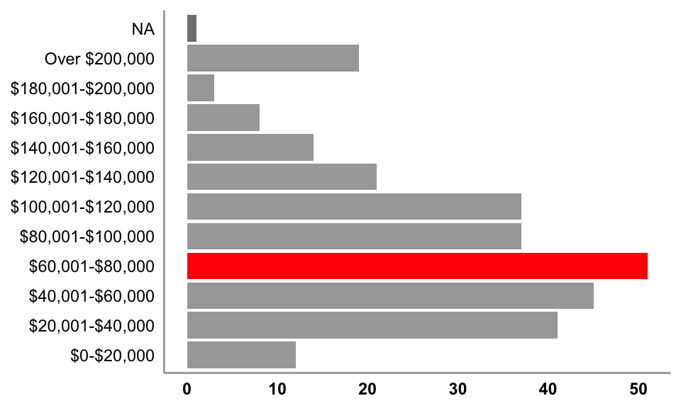

```r
median_income_num <- df_s2_elg %>%
  summarise(median = median(income_num,na.rm = T))

median_income <- median_income_num %>%
  mutate(income_char = case_when(median == 1 ~ "$0-$20,000",
                                 median == 2 ~ "$20,001-$40,000",
                                 median == 3 ~ "$40,001-$60,000",
                                 median == 4 ~ "$60,001-$80,000",
                                 median == 5 ~ "$80,001-$100,000",
                                 median == 6 ~ "$100,001-$120,000",
                                 median == 7 ~ "$120,001-$140,000",
                                 median == 8 ~ "$140,001-$160,000",
                                 median == 9 ~ "$160,001-$180,000",
                                 median == 10 ~ "$180,001-$200,000",
                                 median == 11 ~ "Over $200,000")) %>%
  select(income_char) %>%
  unlist() %>%
  unname()

df_s2_elg %>%
  ggplot(aes(x = income, fill = income == median_income)) +
  geom_bar(show.legend = FALSE) +
  scale_fill_manual(values = c("FALSE" = "grey66", "TRUE" = "red")) +
  theme(panel.grid.major = element_blank(),
        panel.grid.minor = element_blank(),
        panel.background = element_blank(),
        axis.ticks = element_blank(),
        axis.line = element_line(color = "grey66"),
        axis.text.y = element_text(color = "black"),
        axis.text.x = element_text(color = "black",
                                   face = "bold"),
        axis.title.x = element_blank(),
        axis.title.y = element_blank()) +
  coord_flip()
```

Median income: **$60,001-$80,000**.

# Descriptions of Managerial Dominance

Participants read one of the following descriptions:

```r
s2_descriptions %>%
  select(description) %>%
  kbl() %>%
  kable_styling(bootstrap_options = "hover",
                position = "left") %>%
  scroll_box(width = "100%", height = "400px")
```

| description |
| --- |
| I work as an Ecommerce Specialist for a Fabric company that is expanding their virtual presence. As such, I make many nuance and minor decisions about the visual layout as well as the descriptions and… |
| I was up for a promotion at work, and for context should add I was also 34 weeks pregnant. We were working to debut a product our engineering team had been working on. My manager was trying to get me … |
| I work at a school, and I work with my supervisor in the Spring to coordinate testing. Well, my elderly Mom had a doctors appointment for one of those days, and I asked for it off to be with her, thin… |
| I am a worker at a retirement home and for some reason there is a chair in a person’s bathroom which I sit sometimes to take a short break. My boss saw me one time, marched me to her office and had a … |
| I work as a librarian, my manager wanted me to spearhead a project for a new children’s exhibit. I was very busy working on other projects for another manager and told her this. I found out they were … |
| I am a lab manager for a forensics lab. My manager wanted me to have the lab accredited through a national accreditation agency. He ordered me to do an enormous amount of documentation, research, and … |
| I worked at a small business gift shop owned by a local man. One winter, he was annoyed that sales were low. He told me unless I started to sell more, he wouldn’t reimburse me for my Uber rides home a… |
| I worked at Bath and Body Works. Our manager at the time wanted us to give everyone that walked in a hand massage with the lotion. I don’t like touching random people so I wasn’t doing it. She pulled … |
| My manager was trying to get me to file paperwork at a court that I knew was not correct. He was very insecure with himself and his role as manager and wanted to show me that he was boss and I had to … |
| I work in accounting and my supervisor oversees just our sector of accounting, not all of accounting for the whole company. I tend to be more savvy in the accounting software than the rest of my team … |
| It was a project which was awarded to my manager, he couldn’t keep up with the project and then asked for my help in the project completion. While in the process of the getting the project done, my me… |
| I was working as a cashier at a grocery store. I was tasked with asking customers to donate to a children’s charity. That day, many customers declined to donate. The manager, who was responsible for r… |
| My current manager told me, when I was first hired, that I completed my cleaning of the rooms too slow. She wanted me to go faster, so she reminded me that there were many people that were faster than… |
| I was working at a commerical bank a couple of years ago, and my acting director, who was my de facto line manager, became very unappy when he found out that I was responding to the CFO regarding an i… |
| As a marketing coordinator in a fast-paced marketing and sales agency, I found myself under the leadership of a dominant former manager. she was renowned for her assertiveness and uncompromising drive… |
| There was a job that needed to be attempted the way that the company wanted it to be accomplished by following a set of instructions that were left by the client. The supervisor made sure we worked on… |
| Several years back I was working at a gym. There’s usually 3-4 of us at the front desk answering calls, signing people up for membership, giving tours, and answering general questions/concerns people … |
| i work as a nurse in a healthcare facility taking care of patient needs is my role.my manager is my nurse in charge and oversees my roles and allocates duties if necessary.He one day asked me to take … |
| My role is working in disease control for state government and my boss is the program manager. We work in tuberculosis control and treat patients and try to keep the disease from spreading. She also s… |
| I worked as a Program Manager for a large customer. My manager was a Director at our company. He invited himself to a customer meeting that had been scheduled in another city. He wanted to review the … |
| I had a manager that was very dominant when I worked in a warehouse. We would take frozen prepared food and load pallets and trucks. He would constantly threaten to let us go if we did not do things f… |
| I work as a delivery driver and one of my responsibility is to see that the vehicle is washed in the evening of the day or after the day’s work. There are few days that I couldn’t take the vehicle to … |
| I work as a software test engineer and my manager was trying to make me sign off on the latest module we implemented. There was a lot of pieces to test and I was not given enough time, because the dev… |

# Description-specific measures

They were asked the following questions about the randomly-selected description that they saw: open-ended reflection on the employee’s reaction to the manager’s behavior; the impact of the incident on the relationship with the manager; the impact of the incident on the employee’s quitting intentions (as another operationalization of relationship impact); the extent to which the employee complied with what the manager was seeking; and how they would behave if they were the manager in a similar situation.

## Open-ended reactions

What do you think happened as a consequence to the manager’s behavior? Please describe the employee’s reaction to it.

**50-character minimum*

**Paste disabled*

```r
df_s2_elg %>%
  select(react) %>%
  kbl() %>%
  kable_styling(bootstrap_options = "hover",
                position = "left") %>%
  scroll_box(width = "100%", height = "400px")
```

| react |
| --- |
| I think the employee decided to try and clean the rooms faster so he/she could keep their job. |
| Mananger might have been reported to HR and fired or moved |
| If the employee didn’t even speak to the manager, I imagine there were no repercussions |
| sounds like the manager was getting more involved in the employees work and starting to look at it more closely. it also sounded like the manager threatened the employee, saying she cant make the mana… |
| What happened as a consequence of the managers behavior is that he may have lost an employee and more over possibly have HR called on them. The employee felt threatened which is cause for an HR review |
| I think the employees were fearful of upsetting the manager. They were motivated by fear of punishment rather than achieving success. |
| I think the worker was disenfranchised and probably disconnected from work as a result of being treated this way. |
| I feel the manager lost the respect of his employee, considering the language used to describe him/power trip, but the employee was also likely yelled at or publicly rebuked. |
| I imagine the employee felt annoyed and attacked. They might have tried to stand up for themselves but probably ended up trying to appease the manager. |
| The manager’s behavior likely led to decreased morale and trust. The employee felt stressed and disrespected. |
| I think there were no conseuqences for the manager’s behavior and that it made the employee upset and feeling powerless |
| I think the employee is turned off by the manager behavior and dominance. He probably doesnt give a damn about his job anymore |
| It looks to me that the employee probably put up with the manager’s behavior. I doubt he or she reported it to the top-level and I doubt he/she quit. |
| I dont believe there were any consequences for the managers behavior. The employee’s reaction to that was frustration and anger. |
| I believed nothing happened to the managers behavior since he was following a clients very specific detailed oriented instructions. |
| Employee’s probably lost their motivation and didn’t want to be there anymore. They probably also lost some respect for the manager |
| I think the manager didn’t face any repercussions because the employee felt that they couldn’t report their actions to anyone. |
| I think the employee probably did the work, knowing that their job depended on making the terrible manager happy. The manager got promoted and made more money because their were able to get extra work… |
| I think there were negative consequences to the manager’s behavior. I feel that the employee was very unhappy and eventually quit. The manager’s behavior was unacceptable and demoralizes the team. |
| I think the employee probably went to HR despite the manager’s warning. The manager’s behavior was unethical and just morally wrong to expect this out of a pregnant woman and then make threats. The ma… |
| I think it’s likely the employee reported the incident to someone, perhaps in HR. I doubt the manager faced serious consequences, however. |
| I think the employee was unhappy with the manager’s request to do extra work, potentially without being compensated. Usually employees can’t decline requests like that, though, even if they’re tired a… |
| I think the employee tried to work faster at cleaning the room. |
| I believe the employee did a poor job of cleaning an area nearby since they felt like the manager’s way of asking them to complete the task was unnecessary and over-the-top. The employee complied out … |
| The employee probably felt awkward and uncomfrotable and wanted to leave working there after that. |
| I think this made the employee a bit frustrated with the bosses behavior and the employee will continue to act willfully according the the beliefs that they have until the point that the boss may or m… |
| I’m hoping the employee improved their performance and started cleaning the rooms faster. |
| i think the employee filed the wrong thing with the court which ultimately affected her credibility, and the managers, and put her in an uncomfortable situation in both the court and her office. |
| I think the employee never sat on that chair again. I think the employee was embarrassed to be called out and wanted to leave the room with the manager very quickly. |
| Employees were less interested and frustrated. When having meeting you have to be friendly and talk to people nice. Be welcoming |

[output cut: 259 more lines]

## Relationship impact

In your opinion, what was the impact of this incident on the employee’s relationship with this manager? (1 = *It had a strong negative effect on their relationship with their manager* to 7 = *It had a strong positive effect on their relationship with their manager*)

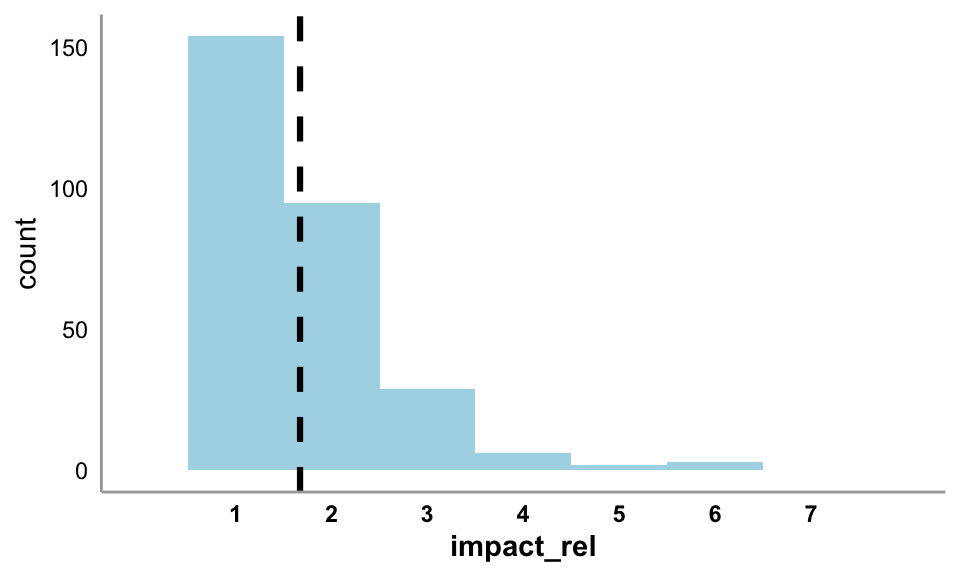

```r
df_s2_elg %>%
  ggplot(aes(x = impact_rel)) +
  geom_histogram(fill = "lightblue",
                 color = NA,
                 binwidth = 1) +
  scale_x_continuous(breaks = seq(1,7,1),
                     limits = c(0,8)) +
  ylab("count") +
  geom_vline(xintercept = mean(df_s2_elg$impact_rel,na.rm = T),
             color = "black",
             linetype = "dashed",
             size = 1.1) +
  theme(panel.grid.major = element_blank(),
        panel.grid.minor = element_blank(),
        panel.background = element_blank(),
        axis.ticks = element_blank(),
        axis.line = element_line(color = "grey66"),
        axis.text.y = element_text(color = "black"),
        axis.text.x = element_text(color = "black",
                                   face = "bold"),
        axis.title.x = element_text(color = "black",
                                   face = "bold"))
```

## Compliance impact

In your opinion, to what extent did the employee comply with what the manager was seeking or requesting? (1 = *They did not comply at all with what the manager was seeking* to 7 = *They completely complied with what the manager was seeking*)

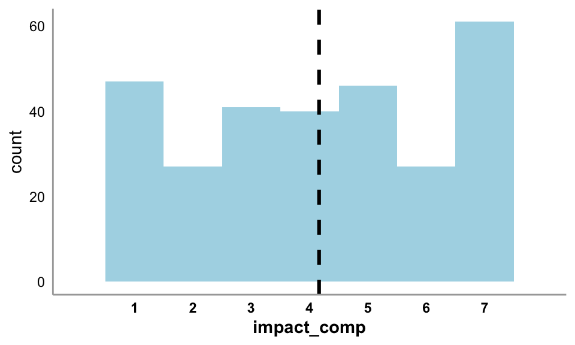

```r
df_s2_elg %>%
  ggplot(aes(x = impact_comp)) +
  geom_histogram(fill = "lightblue",
                 color = NA,
                 binwidth = 1) +
  scale_x_continuous(breaks = seq(1,7,1),
                     limits = c(0,8)) +
  ylab("count") +
  geom_vline(xintercept = mean(df_s2_elg$impact_comp,na.rm = T),
             color = "black",
             linetype = "dashed",
             size = 1.1) +
  theme(panel.grid.major = element_blank(),
        panel.grid.minor = element_blank(),
        panel.background = element_blank(),
        axis.ticks = element_blank(),
        axis.line = element_line(color = "grey66"),
        axis.text.y = element_text(color = "black"),
        axis.text.x = element_text(color = "black",
                                   face = "bold"),
        axis.title.x = element_text(color = "black",
                                   face = "bold"))
```

## Quitting intention impact

In your opinion, what was the impact of this incident on the employee’s intentions to leave this manager or job (such as quitting or transferring)? (1 = *It greatly decreased their intentions to leave their manager* to 7 = *It greatly increased their intentions to leave their manager*)

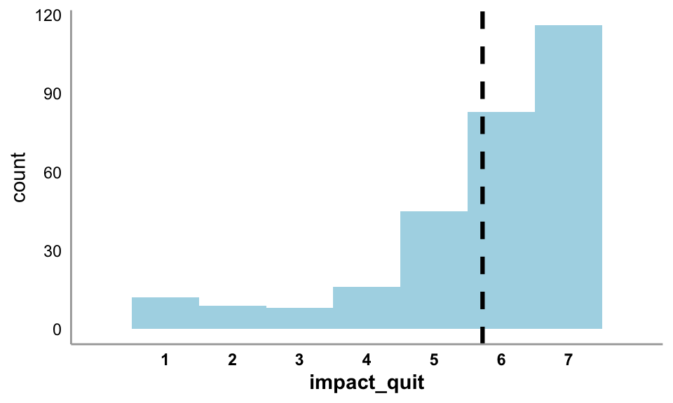

```r
df_s2_elg %>%
  ggplot(aes(x = impact_quit)) +
  geom_histogram(fill = "lightblue",
                 color = NA,
                 binwidth = 1) +
  scale_x_continuous(breaks = seq(1,7,1),
                     limits = c(0,8)) +
  ylab("count") +
  geom_vline(xintercept = mean(df_s2_elg$impact_quit,na.rm = T),
             color = "black",
             linetype = "dashed",
             size = 1.1) +
  theme(panel.grid.major = element_blank(),
        panel.grid.minor = element_blank(),
        panel.background = element_blank(),
        axis.ticks = element_blank(),
        axis.line = element_line(color = "grey66"),
        axis.text.y = element_text(color = "black"),
        axis.text.x = element_text(color = "black",
                                   face = "bold"),
        axis.title.x = element_text(color = "black",
                                   face = "bold"))
```

## Intentions of dominant behavior

In this situation, the manager wanted the employee to do something specific:

[TASK FROM MANAGER].

If you were a manager in this kind of situation, how likely would you be to act in the way the manager did, as described earlier? (1 = *Not at All Likely* to 5 = *Extremely Likely*)

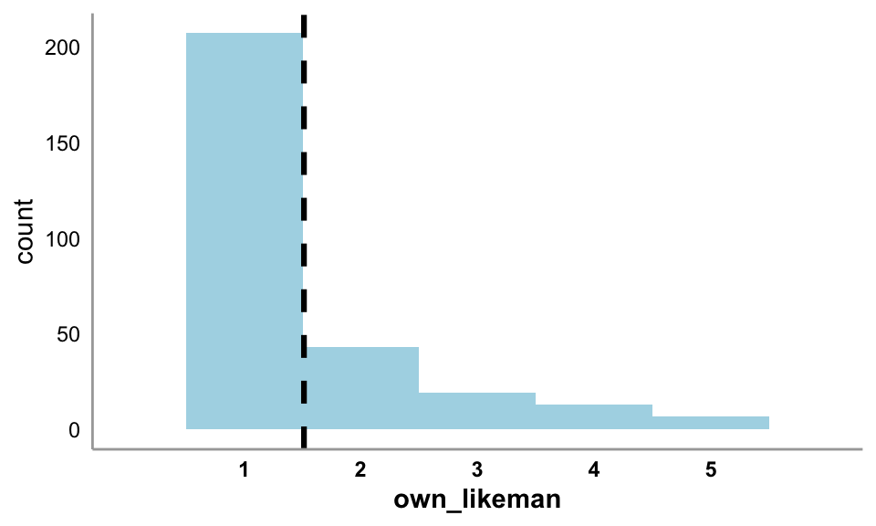

```r
df_s2_elg %>%
  ggplot(aes(x = own_likeman)) +
  geom_histogram(fill = "lightblue",
                 color = NA,
                 binwidth = 1) +
  scale_x_continuous(breaks = seq(1,5,1),
                     limits = c(0,6)) +
  ylab("count") +
  geom_vline(xintercept = mean(df_s2_elg$own_likeman,na.rm = T),
             color = "black",
             linetype = "dashed",
             size = 1.1) +
  theme(panel.grid.major = element_blank(),
        panel.grid.minor = element_blank(),
        panel.background = element_blank(),
        axis.ticks = element_blank(),
        axis.line = element_line(color = "grey66"),
        axis.text.y = element_text(color = "black"),
        axis.text.x = element_text(color = "black",
                                   face = "bold"),
        axis.title.x = element_text(color = "black",
                                   face = "bold"))
```

## Competitive worldview

They completed the Competitive Worldview scale at the end of the survey.

From [Perry et al., 2013](https://doi.org/10.1016/j.jrp.2012.10.004)

1 = *Strongly Disagree* to 7 = *Strongly Agree*

1. It’s a dog-eat-dog world where you have to be ruthless at times
2. Life is not governed by the “survival of the fittest.” We should let compassion and moral laws be our guide [R]
3. There is really no such thing as “right” and “wrong.” It all boils down to what you can get away with
4. One of the most useful skills a person should develop is how to look someone straight in the eye and lie convincingly
5. It is better to be loved than to be feared [R]
6. My knowledge and experience tell me that the social world we live in is basically a competitive “jungle” in which the fittest survive and succeed, in which power, wealth, and winning are everything, and might is right
7. Do unto others as you would have them do unto you, and never do anything unfair to someone else [R]
8. Basically people are objects to be quietly and coolly manipulated for one’s own benefit
9. Honesty is the best policy in all cases [R]
10. One should give others the benefit of the doubt. Most people are trustworthy if you have faith in them [R]

R indicates a reverse-scored item.

Cronbach’s alpha = 0.78

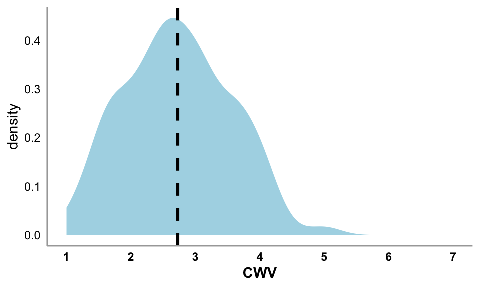

```r
df_s2_elg %>%
  ggplot(aes(x = CWV)) +
  geom_density(fill = "lightblue",
                 color = NA) +
  scale_x_continuous(breaks = seq(1,7,1),
                     limits = c(1,7)) +
  ylab("density") +
  geom_vline(xintercept = mean(df_s2_elg$CWV,na.rm = T),
             color = "black",
             linetype = "dashed",
             size = 1.1) +
  theme(panel.grid.major = element_blank(),
        panel.grid.minor = element_blank(),
        panel.background = element_blank(),
        axis.ticks = element_blank(),
        axis.line = element_line(color = "grey66"),
        axis.text.y = element_text(color = "black"),
        axis.text.x = element_text(color = "black",
                                   face = "bold"),
        axis.title.x = element_text(color = "black",
                                   face = "bold"))
```

# Analysis

## Linear Random Effects Model 1

**Predictor:** Competitive worldview.

**Outcome:** Dominant behavior (like the manager).

**Random effect:** Description.

**Controls:** Age, race (white = 1; non-white = 0), gender (man = 1; non-man = 0), education (numeric), income (numeric).

```r
m1 <- lmerTest::lmer(own_likeman ~ CWV + (1|og_pid) + age + white + man + edu_num + income_num,data = df_s2_elg)

eta_table <- eta_squared(m1)
etas_for_table <- c(NA,eta_table$Eta2_partial)
apa_lm <- apa_print(m1)
table_for_print <- apa_lm$table %>%
  mutate(eta2 = round(etas_for_table,3))

kbl(table_for_print) %>%
  kable_styling(bootstrap_options = "hover",
                full_width = F,
                position = "left")
```

| term | estimate | conf.int | statistic | df | p.value | eta2 |
| --- | --- | --- | --- | --- | --- | --- |
| Intercept | 1.58 | [0.86, 2.30] | 4.32 | 263.87 | < .001 | NA |
| CWV | 0.18 | [0.05, 0.31] | 2.67 | 254.57 | .008 | 0.027 |
| Age | -0.01 | [-0.02, 0.00] | -2.50 | 256.68 | .013 | 0.024 |
| White | 0.03 | [-0.20, 0.25] | 0.26 | 249.78 | .798 | 0.000 |
| Man | 0.01 | [-0.20, 0.23] | 0.13 | 253.32 | .893 | 0.000 |
| Edu num | -0.03 | [-0.14, 0.07] | -0.63 | 259.20 | .531 | 0.002 |
| Income num | 0.01 | [-0.04, 0.05] | 0.24 | 255.53 | .809 | 0.000 |

## Linear Random Effects Model 2

**Predictor:** Competitive worldview.

**Outcome:** Predicted relationship impact.

**Random effect:** Description.

**Controls:** Age, race (white = 1; non-white = 0), gender (man = 1; non-man = 0), education (numeric), income (numeric).

```r
m1 <- lmerTest::lmer(impact_rel ~ CWV + (1|og_pid) + age + white + man + edu_num + income_num,data = df_s2_elg)

eta_table <- eta_squared(m1)
etas_for_table <- c(NA,eta_table$Eta2_partial)
apa_lm <- apa_print(m1)
table_for_print <- apa_lm$table %>%
  mutate(eta2 = round(etas_for_table,3))

kbl(table_for_print) %>%
  kable_styling(bootstrap_options = "hover",
                full_width = F,
                position = "left")
```

| term | estimate | conf.int | statistic | df | p.value | eta2 |
| --- | --- | --- | --- | --- | --- | --- |
| Intercept | 0.81 | [0.12, 1.49] | 2.31 | 265.57 | .022 | NA |
| CWV | 0.32 | [0.18, 0.45] | 4.74 | 261.03 | < .001 | 0.079 |
| Age | -0.01 | [-0.02, 0.00] | -1.44 | 263.89 | .152 | 0.008 |
| White | 0.12 | [-0.11, 0.34] | 1.01 | 252.81 | .312 | 0.004 |
| Man | 0.02 | [-0.20, 0.23] | 0.16 | 258.72 | .876 | 0.000 |
| Edu num | 0.04 | [-0.07, 0.14] | 0.71 | 266.15 | .477 | 0.002 |
| Income num | 0.01 | [-0.03, 0.06] | 0.63 | 262.34 | .531 | 0.001 |

## Random Effects Mediation Model 1

**Predictor:** Competitive worldview.

**Mediator:** Predicted relationship impact.

**Outcome:** Dominant behavior (like the manager).

**Random effect:** Description.

**Controls:** Age, race (white = 1; non-white = 0), gender (man = 1; non-man = 0), education (numeric), income (numeric).

```r
# Step 1: Fit the mediator model
med.fit <- lme4::lmer(impact_rel ~ CWV + (1|og_pid) + age + white + man + edu_num + income_num, df_s2_elg, REML=F)

# Step 2: Fit the outcome model
out.fit <- lme4::lmer(own_likeman ~ impact_rel + CWV + (1|og_pid) + age + white + man + edu_num + income_num, df_s2_elg, REML=F)

# Step 3: Conduct the mediation analysis
med.out <- mediation::mediate(med.fit, out.fit,
                   treat = "CWV",
                   mediator = "impact_rel",
                   boot = FALSE,
                   sims = 10000,
                   boot.ci.type="bca")

# Step 4: Create table
med_results <- data.frame(
  Effect = c("ACME (indirect)", "ADE (direct)", "Total Effect", "Prop. Mediated"),
  Estimate = round(c(med.out$d0, med.out$z0, med.out$tau.coef, med.out$n0), 3),
  `95% CI Lower` = round(c(med.out$d0.ci[1], med.out$z0.ci[1], med.out$tau.ci[1], med.out$n0.ci[1]), 3),
  `95% CI Upper` = round(c(med.out$d0.ci[2], med.out$z0.ci[2], med.out$tau.ci[2], med.out$n0.ci[2]), 3),
  `p-value` = signif(c(med.out$d0.p, med.out$z0.p, med.out$tau.p, med.out$n0.p), 3)
)

kbl(med_results) %>%
  kable_styling(bootstrap_options = "hover",
                full_width = F,
                position = "left")
```

| Effect | Estimate | X95..CI.Lower | X95..CI.Upper | p.value |
| --- | --- | --- | --- | --- |
| ACME (indirect) | 0.107 | 0.055 | 0.169 | 0.000 |
| ADE (direct) | 0.073 | -0.054 | 0.201 | 0.272 |
| Total Effect | 0.180 | 0.049 | 0.312 | 0.008 |
| Prop. Mediated | 0.590 | 0.275 | 1.809 | 0.008 |

## Random Effects Mediation Model 2

**Predictor:** Competitive worldview.

**Mediators:** Predicted relationship impact (path 1), predicted compliance impact (path 2).

**Outcome:** Dominant behavior (like the manager).

**Random effect:** Description.

**Controls:** Age, race (white = 1; non-white = 0), gender (man = 1; non-man = 0), education (numeric), income (numeric).

```r
predictor  <- "CWV"
outcome    <- "own_likeman"
mediators  <- c("impact_rel", "impact_comp")
controls   <- c("age","white","man","edu_num","income_num")
cluster_id <- "og_pid"

vars_needed <- c(outcome, predictor, mediators, controls, cluster_id)
df_cc <- df_s2_elg[complete.cases(df_s2_elg[, vars_needed]), vars_needed]

f_c <- as.formula(
  paste0(outcome, " ~ ", predictor, " + ",
         paste(controls, collapse = " + "),
         " + (1|", cluster_id, ")")
)

m_c <- lmerTest::lmer(f_c, data = df_cc)

c_row <- {
  sm <- summary(m_c)
  est <- sm$coefficients[predictor, "Estimate"]
  se  <- sm$coefficients[predictor, "Std. Error"]
  p   <- sm$coefficients[predictor, "Pr(>|t|)"]
  ci <- suppressMessages(confint(m_c, parm = predictor, method = "Wald"))
  tibble(
    label = "c",
    est = as.numeric(est),
    se  = as.numeric(se),
    ci.lower = as.numeric(ci[1]),
    ci.upper = as.numeric(ci[2]),
    pvalue = as.numeric(p)
  )
}

controls_str <- paste(controls, collapse = " + ")

model_med <- paste0(
  mediators[1], " ~ a1*", predictor, " + ", controls_str, "\n",
  mediators[2], " ~ a2*", predictor, " + ", controls_str, "\n\n",
  mediators[1], " ~~ ", mediators[2], "\n\n",
  outcome, " ~ b1*", mediators[1], " + b2*", mediators[2],
  " + c_prime*", predictor, " + ", controls_str, "\n\n",
  "ind1 := a1*b1\n",
  "ind2 := a2*b2\n",
  "ind_total := ind1 + ind2\n"
)

fit_med <- sem(
  model_med,
  data = df_cc,
  cluster = cluster_id,
  se = "robust.cluster"
)

keep_labels <- c("a1","a2","b1","b2","c_prime","ind1","ind2","ind_total")

lavaan_rows <- parameterEstimates(fit_med, ci = TRUE) %>%
  filter(label %in% keep_labels) %>%
  select(label, est, se, ci.lower, ci.upper, pvalue)


cprime_est <- lavaan_rows$est[lavaan_rows$label == "c_prime"]
indtot_est <- lavaan_rows$est[lavaan_rows$label == "ind_total"]

total_row <- c_row %>%
  mutate(label = "total")

final_table <- bind_rows(
  lavaan_rows,
  c_row,
  total_row
) %>%
  mutate(
    label = factor(
      label,
      levels = c("a1","a2","b1","b2","c","c_prime","ind1","ind2","ind_total","total")
    )
  ) %>%
  arrange(label)

kbl(final_table) %>%
  kable_styling(bootstrap_options = "hover",
                full_width = F,
                position = "left")
```

| label | est | se | ci.lower | ci.upper | pvalue |
| --- | --- | --- | --- | --- | --- |
| a1 | 0.3164818 | 0.0768638 | 0.1658315 | 0.4671320 | 0.0000383 |
| a2 | -0.1271959 | 0.1799597 | -0.4799104 | 0.2255187 | 0.4796895 |
| b1 | 0.3502473 | 0.0540208 | 0.2443685 | 0.4561261 | 0.0000000 |
| b2 | 0.0474555 | 0.0436302 | -0.0380580 | 0.1329691 | 0.2767375 |
| c | 0.1807827 | 0.0677191 | 0.0480556 | 0.3135098 | 0.0080827 |
| c_prime | 0.0310457 | 0.0696239 | -0.1054146 | 0.1675060 | 0.6556649 |
| ind1 | 0.1108469 | 0.0326844 | 0.0467865 | 0.1749072 | 0.0006953 |
| ind2 | -0.0060361 | 0.0108752 | -0.0273511 | 0.0152788 | 0.5788686 |
| ind_total | 0.1048107 | 0.0350383 | 0.0361369 | 0.1734846 | 0.0027778 |
| total | 0.1807827 | 0.0677191 | 0.0480556 | 0.3135098 | 0.0080827 |